# Predicting Wages in R

Rob James

Sept 2017

Predictive Analytics Assign 1

### Aim of Project

The Aim of the project was to try and create a simple Multi-Variate Regression model which could be used to predict a Worker’s Weekly Earnings.

### Key Findings

# Data Exploration

Firstly some simple variables were extracted

```r
weeklyearnings <- csv$Weekly.Earnings
weeklyhrsworked <- csv$Weekly.Hours.Worked
age <- csv$Age
sleeping <- csv$Sleeping
socialising <-csv$Socializing...Relaxing
foodprep <- csv$Food...Drink.Prep
volunteering <- csv$Volunteering
employ <- csv$Employment.Status
```

Next Gender was converted to a binary variable ‘maleyes’ and Education.level was converted into a numeric variable

```r
maleyes <- as.numeric(csv$Gender == "Male")

education <-  ifelse(csv$Education.Level == '9th Grade',1,
              ifelse(csv$Education.Level == '10th Grade',2,
              ifelse(csv$Education.Level == '11th Grade',3,
              ifelse(csv$Education.Level == '12th Grade',4,
              ifelse(csv$Education.Level == 'High School',5,
              ifelse(csv$Education.Level == 'Some College',6,
              ifelse(csv$Education.Level == 'Associate Degree',7,
              ifelse(csv$Education.Level == 'Bachelor',8,
              ifelse(csv$Education.Level == 'Master',9,
              ifelse(csv$Education.Level == 'Doctoral Degree',10,
              ifelse(csv$Education.Level == 'Doctoral Degree',11,0)))))))))))
```

A Preliminary Data frame was formed.

This data frame was then subset to remove all records which had 0 or less Hrs worked / Wages or unemployed workers

```r
nozero <- subset(data,data[,2] >0)

nozero <- subset(nozero,nozero[,1] >0)

nozero <- subset(nozero,nozero[,3] == 'Employed')
```

Then a payrate column was created by dividing weekly wages by weekly hrs worked

```r
nozero$payrate <- with(nozero, weeklyearnings / weeklyhrsworked)
```

### Density Plots

Next the data’s distributions were explored through density plots:

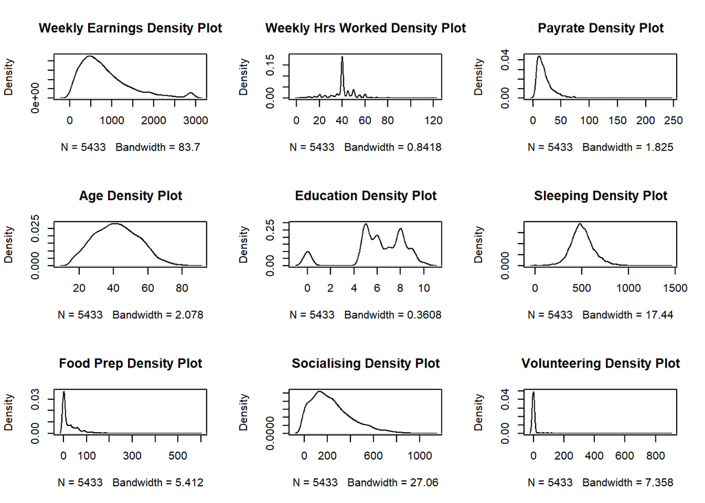

Next several of the variables were square root transformed to make the distributions easier to analyse. These were then placed in a new dataframe

```r
sqrtweeklyearnings <-sqrt(nozero$weeklyearnings)
sqrtsocial <- sqrt(nozero$socialising)
sqrtfoodprep <-sqrt(nozero$foodprep)
sqrtvolunteering <- sqrt(nozero$volunteering)
```

Here are the density and scatter plots for the transformed variables

### Density Plots 2

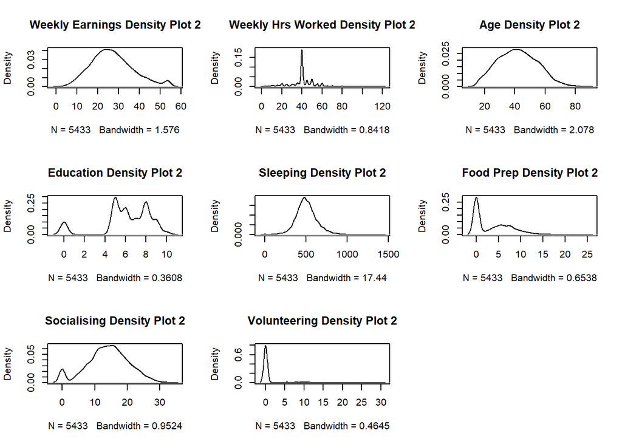

### Scatter plots 2

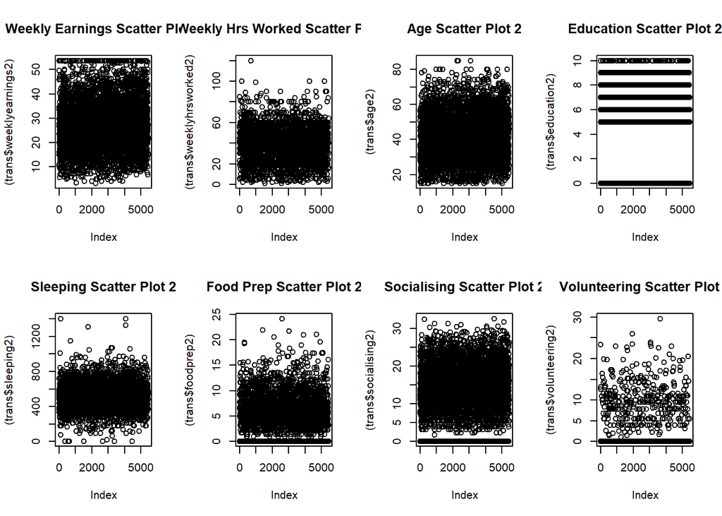

A correlation plot was created to see how the variables correlated together

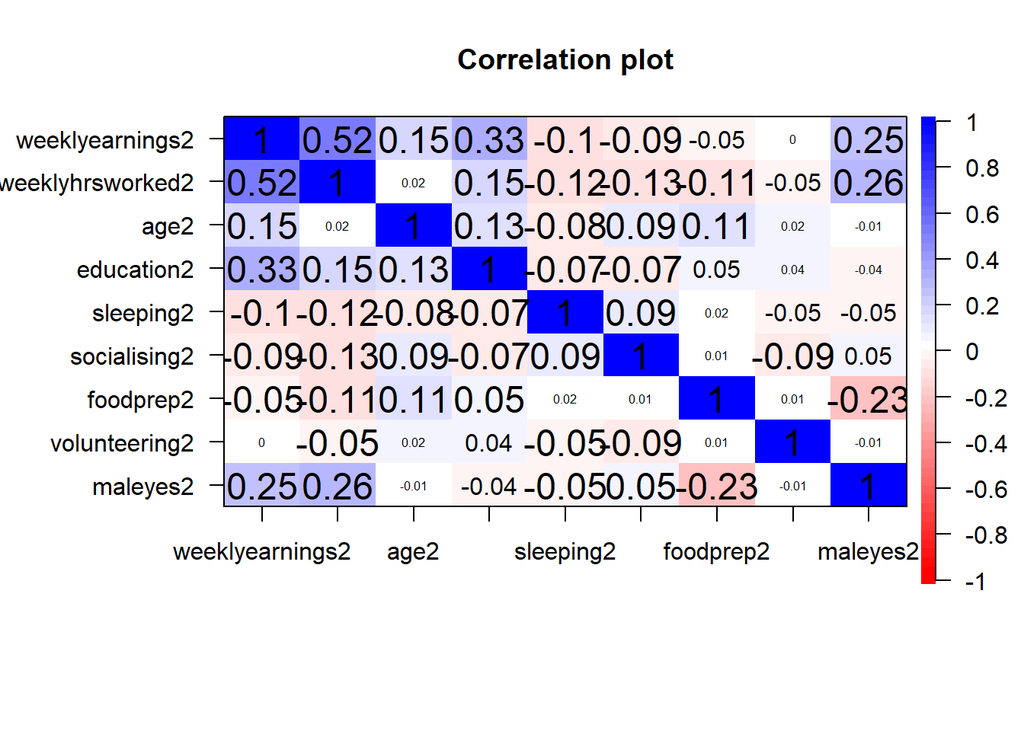

As we can see in the plot, the data has pretty poor correlation between variables. Only weeklyhrsworked2 has over 0.5 which is still a weak correlation - we would likely expect weak performance from the predictive model as the data doesn’t correlate well.

A sample was then taken to split the data into 80% training, 20% test

```r
indextrain <- sample.int(nrow(trans),round(nrow(trans) * 0.8))

trainingsample <- trans[indextrain,]
validationsample <- trans[-indextrain,]
```

# Model Building

Firstly a model was created using all variables:

```
##
## Call:
## lm(formula = weeklyearnings2 ~ ., data = trainingsample)
##
## Residuals:
##     Min      1Q  Median      3Q     Max
## -30.822  -5.175  -1.050   3.923  33.996
##
## Coefficients:
##                    Estimate Std. Error t value Pr(>|t|)
## (Intercept)       2.7295667  0.8877672   3.075  0.00212 **
## weeklyhrsworked2  0.3438180  0.0104813  32.803  < 2e-16 ***
## age2              0.0876331  0.0097064   9.028  < 2e-16 ***
## education2        1.0685637  0.0527943  20.240  < 2e-16 ***
## sleeping2        -0.0011815  0.0009579  -1.233  0.21748
## socialising2     -0.0575073  0.0198728  -2.894  0.00383 **
## foodprep2         0.0325352  0.0309496   1.051  0.29321
## volunteering2    -0.0060345  0.0431828  -0.140  0.88887
## maleyes2          3.3744101  0.2615654  12.901  < 2e-16 ***
## ---
## Signif. codes:  0 '***' 0.001 '**' 0.01 '*' 0.05 '.' 0.1 ' ' 1
##
## Residual standard error: 8.07 on 4337 degrees of freedom
## Multiple R-squared:  0.3607, Adjusted R-squared:  0.3595
## F-statistic: 305.9 on 8 and 4337 DF,  p-value: < 2.2e-16
```

However the performance was pretty poor so only the folowing variables with reasonable correlation scores were selected for the next model:

- weeklyhoursworked2
- age2
- education3
- maleyes2

```
##
## Call:
## lm(formula = weeklyearnings2 ~ weeklyhrsworked2 + age2 + education2 +
##     maleyes2, data = trainingsample)
##
## Residuals:
##     Min      1Q  Median      3Q     Max
## -31.006  -5.185  -1.004   3.901  33.643
##
## Coefficients:
##                  Estimate Std. Error t value Pr(>|t|)
## (Intercept)      1.252142   0.614941   2.036   0.0418 *
## weeklyhrsworked2 0.348272   0.010324  33.735   <2e-16 ***
## age2             0.087246   0.009593   9.094   <2e-16 ***
## education2       1.080916   0.052648  20.531   <2e-16 ***
## maleyes2         3.255650   0.255340  12.750   <2e-16 ***
## ---
## Signif. codes:  0 '***' 0.001 '**' 0.01 '*' 0.05 '.' 0.1 ' ' 1
##
## Residual standard error: 8.077 on 4341 degrees of freedom
## Multiple R-squared:  0.359,  Adjusted R-squared:  0.3584
## F-statistic: 607.8 on 4 and 4341 DF,  p-value: < 2.2e-16
```

```
##
## Call:
## lm(formula = weeklyearnings2 ~ weeklyhrsworked2 + education2 +
##     maleyes2, data = trainingsample)
##
## Residuals:
##     Min      1Q  Median      3Q     Max
## -30.989  -5.329  -1.073   4.009  35.180
##
## Coefficients:
##                  Estimate Std. Error t value Pr(>|t|)
## (Intercept)       4.60591    0.49671   9.273   <2e-16 ***
## weeklyhrsworked2  0.34815    0.01042  33.410   <2e-16 ***
## education2        1.13521    0.05280  21.501   <2e-16 ***
## maleyes2          3.23000    0.25772  12.533   <2e-16 ***
## ---
## Signif. codes:  0 '***' 0.001 '**' 0.01 '*' 0.05 '.' 0.1 ' ' 1
##
## Residual standard error: 8.152 on 4342 degrees of freedom
## Multiple R-squared:  0.3468, Adjusted R-squared:  0.3463
## F-statistic: 768.4 on 3 and 4342 DF,  p-value: < 2.2e-16
```

```
##
## Call:
## lm(formula = weeklyearnings2 ~ weeklyhrsworked2 + education2,
##     data = trainingsample)
##
## Residuals:
##     Min      1Q  Median      3Q     Max
## -33.197  -5.576  -1.241   4.260  35.313
##
## Coefficients:
##                  Estimate Std. Error t value Pr(>|t|)
## (Intercept)       4.99618    0.50456   9.902   <2e-16 ***
## weeklyhrsworked2  0.38293    0.01022  37.457   <2e-16 ***
## education2        1.08467    0.05358  20.243   <2e-16 ***
## ---
## Signif. codes:  0 '***' 0.001 '**' 0.01 '*' 0.05 '.' 0.1 ' ' 1
##
## Residual standard error: 8.298 on 4343 degrees of freedom
## Multiple R-squared:  0.3232, Adjusted R-squared:  0.3228
## F-statistic:  1037 on 2 and 4343 DF,  p-value: < 2.2e-16
```

Here we can see that the model has an Multiple R2 of ~0.33. This means the Model can only explain ~33% of the variance in the data. This is pretty poor performance; likely because the data input into the model is poor.

Here are some plots of the final model:

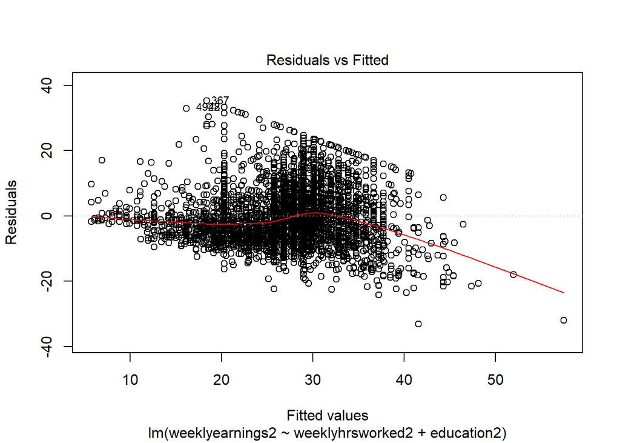

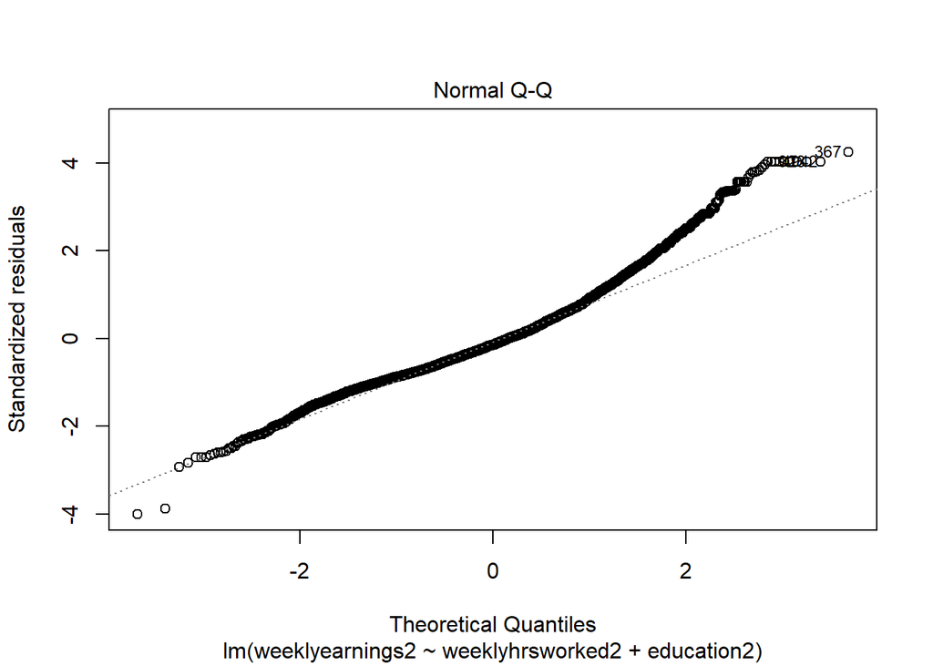

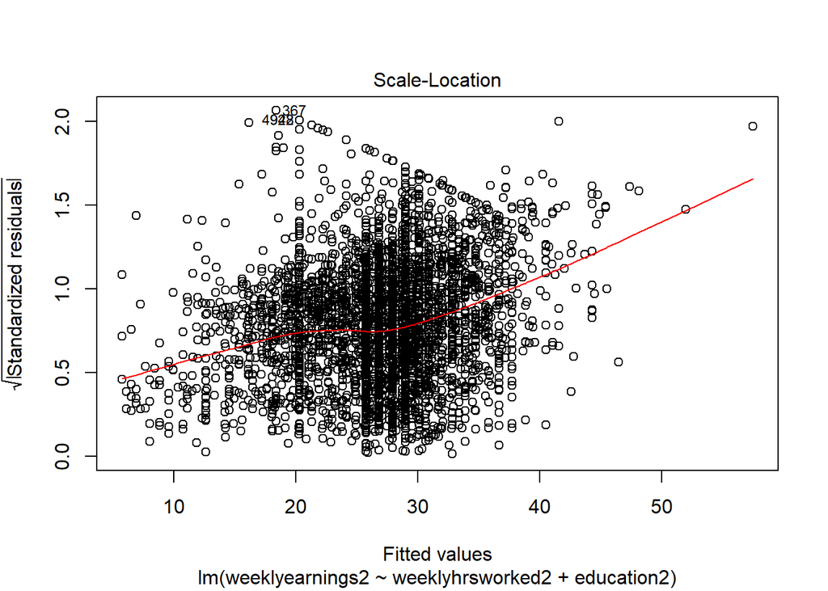

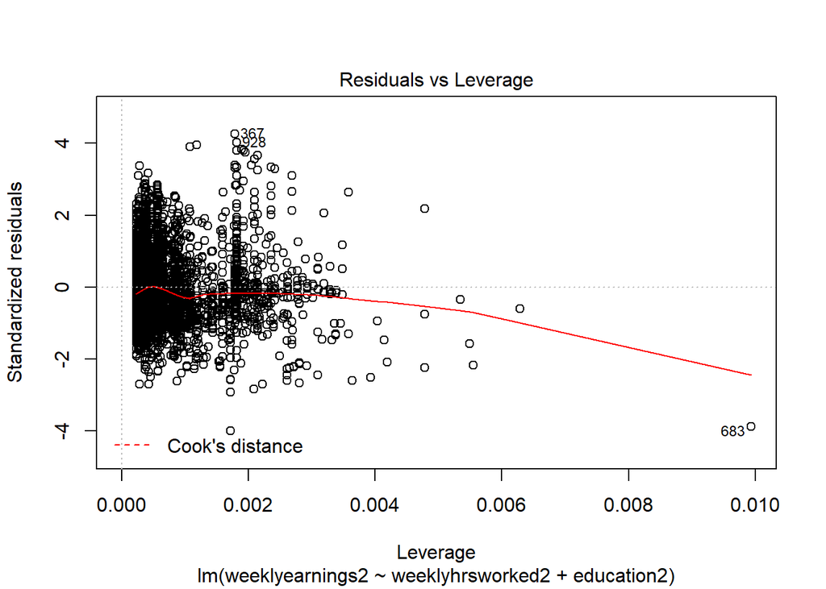

# Predicting

Firstly Weekly Earnings were predicted on the training set

```r
trainingsample$pred.weekearnings <- predict(fit4, newdata = subset(trainingsample, select = c(weeklyhrsworked2,education2)))

train.corr <- round(cor(trainingsample$pred.weekearnings, trainingsample$weeklyearnings2), 2) # 0.57 #
train.RMSE <- round(sqrt(mean((trainingsample$pred.weekearnings^2 - trainingsample$weeklyearnings2^2)^2))) # 543 #
train.MAE <- round(mean(abs(trainingsample$pred.weekearnings^2 - trainingsample$weeklyearnings2^2))) # 368 #
c("Correlation","RMSE","MAE")
```

```
## [1] "Correlation" "RMSE"        "MAE"
```

```
## [1]   0.3249 544.0000 366.0000
```

Next Weekly Earnings were predicted on the Test / Validation sample

```r
# Validation #
validationsample$pred.weekearnings <- predict(fit4, newdata = subset(validationsample, select = c(weeklyhrsworked2,education2)))

valid.corr <- round(cor(validationsample$pred.weekearnings, validationsample$weeklyearnings2), 2) # 0.57 #
valid.RMSE <- round(sqrt(mean((validationsample$pred.weekearnings^2 - validationsample$weeklyearnings2^2)^2))) # 543 #
valid.MAE <- round(mean(abs(validationsample$pred.weekearnings^2 - validationsample$weeklyearnings2^2))) # 368 #
c("Correlation","RMSE","MAE")
```

```
## [1] "Correlation" "RMSE"        "MAE"
```

```
## [1]   0.3481 542.0000 369.0000
```

Here is the VIF for the model

```
## weeklyhrsworked2       education2
##          1.02107          1.02107
```